# M2_883_20211_PEC1_Solucion_executed2

[figure not shown]

M2.883 · Aprendizaje por refuerzo

2021-1 · Máster universitario en Ciencia de datos (*Data science*)

Estudios de Informática, Multimedia y Telecomunicación

# PEC 1 - Soluciones tabulares

En esta práctica implementaremos los diferentes métodos de aprendizaje por refuerzo vistos en la Parte I y II del curso. En concreto, nos centraremos en la definición de un entorno e implementaremos los diferentes métodos para buscar una solución óptima del problema.

**Importante: La entrega debe hacerse en formato notebook y en formato html donde se vea el código, los resultados y comentarios de cada ejercicio. Es decir, deben entregarse dos ficheros: uno con extensión .ipynb y otro .html. Para exportar el notebook a html puede hacerse desde el menú File $\to$ Download as $\to$ HTML.**

## 0. El entorno **CliffWalking**

El entorno **CliffWalking** consiste en un agente que se mueve en una cuadrícula de dimensiones 12x4 (ancho x alto). En cada paso, el agente tiene 4 opciones de acción o movimiento: ARRIBA, ABAJO, DERECHA, IZQUIERDA. El agente siempre sale de la misma casilla [0, 3] (esquina abajo izquierda) y el juego termina cuando el agente llega a la casilla de llegada [11, 3] (esquina abajo derecha). La posición de cada casilla viene dada por una pareja de números naturales [x, y], donde la posición de la esquina de arriba a la izquierda sería el origen de coordenadas [0, 0].

El entorno se corresponde con el ejemplo 'Cuadrícula con precipicio' explicado en la sección 3.2.1. del módulo "Métodos de Diferencia Temporal". El problema radica en que en todas las casillas la recompensa inmediata es R=-1 excepto en las casillas que unen en línea recta la casilla de salida de la de llegada, casillas [1, 3] a [10, 3]. En estas casillas, que simulan un precipicio, la recompensa es R=-100 y se vuelve a la casilla inicial.

[figure not shown]

Fuente: Sutton & Barto, 2018

El código para implementar este entorno, que se encuentra disponible en el fichero adjunto `cliff_env.py`, ha sido adaptado del siguiente enlace: https://pypi.org/project/gym-gridworlds/

Vamos a empezar cargando el entorno y ver qué características tiene, ejecutando un episodio de prueba.

### 0.1. Carga de datos

El siguiente código carga los paquetes necesarios para ejecutar el ejemplo, crea el entorno mediante la instanciación de un objeto de la clase `CliffEnv` (importada del archivo adjunto `cliff_env.py`) e imprime por pantalla la dimensión del espacio de acciones (0=arriba, 1=derecha, 2=abajo y 3=izquierda), el espacio de observaciones (una tupla que indica la posición del agente en la cuadrícula) y el rango de la variable de recompensa (cuyo valor es -1 o -100 dependiendo de la casilla visitada y que por tanto va de menos infinito a más infinito).

```python
!pip install gym
```

```python
import gym
import numpy as np
import cliff_env as cenv

env=cenv.CliffEnv()
print("Action space is {} ".format(env.action_space))
print("Observation space is {} ".format(env.observation_space))
print("Reward range is {} ".format(env.reward_range))
```

```
Action space is Discrete(4)
Observation space is Tuple(Discrete(12), Discrete(4))
Reward range is (-inf, inf)
```

### 0.2. Ejecución de un episodio

A continuación, realizaremos la ejecución de un episodio del entorno CliffWalking utilizando un agente que selecciona las acciones de forma aleatoria.

```python
# Inicializamos el entorno
obs = env.reset()
t, total_reward, done = 0, 0, False

print("Obs inicial: {} ".format(obs))

switch_action = {
        0: "U",
        1: "R",
        2: "D",
        3: "L",
    }

while not done:

    # Elegir una acción aleatoria (ésta es la implementación del agente)
    action = env.action_space.sample()

    # Ejecutar la acción y esperar la respuesta del entorno
    new_obs, reward, done, info = env.step(action)

    # Imprimir time-step
    print("Action: {} -> Obs: {} and reward: {}".format(switch_action[action], new_obs, reward))

    # Actualizar variables
    obs = new_obs
    total_reward += reward
    t += 1

print("Episode finished after {} timesteps and reward was {} ".format(t, total_reward))
env.close()
```

```
Obs inicial: (0, 3)
Action: L -> Obs: (0, 3) and reward: -1
Action: U -> Obs: (0, 2) and reward: -1
Action: R -> Obs: (1, 2) and reward: -1
Action: R -> Obs: (2, 2) and reward: -1
Action: D -> Obs: (0, 3) and reward: -100
Action: U -> Obs: (0, 2) and reward: -1
Action: U -> Obs: (0, 1) and reward: -1
Action: U -> Obs: (0, 0) and reward: -1
Action: D -> Obs: (0, 1) and reward: -1
Action: L -> Obs: (0, 1) and reward: -1
Action: D -> Obs: (0, 2) and reward: -1
Action: U -> Obs: (0, 1) and reward: -1
Action: L -> Obs: (0, 1) and reward: -1
Action: D -> Obs: (0, 2) and reward: -1
Action: R -> Obs: (1, 2) and reward: -1
Action: D -> Obs: (0, 3) and reward: -100
Action: D -> Obs: (0, 3) and reward: -1
Action: R -> Obs: (0, 3) and reward: -100
Action: D -> Obs: (0, 3) and reward: -1
Action: L -> Obs: (0, 3) and reward: -1
Action: R -> Obs: (0, 3) and reward: -100
Action: R -> Obs: (0, 3) and reward: -100
Action: L -> Obs: (0, 3) and reward: -1
Action: U -> Obs: (0, 2) and reward: -1
Action: R -> Obs: (1, 2) and reward: -1
Action: L -> Obs: (0, 2) and reward: -1
Action: D -> Obs: (0, 3) and reward: -1
Action: L -> Obs: (0, 3) and reward: -1
Action: D -> Obs: (0, 3) and reward: -1
Action: U -> Obs: (0, 2) and reward: -1
Action: D -> Obs: (0, 3) and reward: -1
Action: D -> Obs: (0, 3) and reward: -1
Action: U -> Obs: (0, 2) and reward: -1
Action: D -> Obs: (0, 3) and reward: -1
Action: D -> Obs: (0, 3) and reward: -1
Action: U -> Obs: (0, 2) and reward: -1
Action: L -> Obs: (0, 2) and reward: -1
Action: U -> Obs: (0, 1) and reward: -1
Action: D -> Obs: (0, 2) and reward: -1
```

[output cut: 2496 more lines]

```
Action: U -> Obs: (11, 1) and reward: -1
Action: L -> Obs: (10, 1) and reward: -1
Action: U -> Obs: (10, 0) and reward: -1
Action: R -> Obs: (11, 0) and reward: -1
Action: R -> Obs: (11, 0) and reward: -1
Action: D -> Obs: (11, 1) and reward: -1
Action: R -> Obs: (11, 1) and reward: -1
Action: L -> Obs: (10, 1) and reward: -1
Action: R -> Obs: (11, 1) and reward: -1
Action: D -> Obs: (11, 2) and reward: -1
Action: R -> Obs: (11, 2) and reward: -1
Action: U -> Obs: (11, 1) and reward: -1
Action: D -> Obs: (11, 2) and reward: -1
Action: D -> Obs: (11, 3) and reward: -1
Episode finished after 2549 timesteps and reward was -23933
```

## 1. Modificación del entorno (1,5 puntos)

El entorno CliffWalking tiene varios parámetros que pueden ser modificados:

- La dimensión de la cuadrícula.
- La posición del precipicio.
- La posición de las casillas de salida y de llegada.
- La recompensa inmediata.

**Ejercicio 1.1** (0,75 puntos)

Modificar el codigo de CliffWalking (fichero adjunto `cliff_env.py`) para que represente las propiedades de la cuadrícula descritas a continuación.

- Cuadrícula 5x11
- Posición del precipicio = Casillas [1,0], [2,0], [3,0], [4,0], [5,0], [6,0], [7,0], [8,0] y [9,0]
- Casilla de inicio [0,0]
- Casilla final [10,0]
- Recompensa en casillas normales = -1
- Recompensa en casillas del precipicio = -500 (y volvemos a la casilla de salida)

Guardar el entorno modificado en el archivo `cliff_env_v2.py`, en la misma carpeta que el original. Este archivo debe entregarse junto a los archivos de este notebook (.ipynb y .html).

```python
import gym
import numpy as np
import cliff_env_v2 as ce2

env=ce2.CliffEnv()
print("Action space is {} ".format(env.action_space))
print("Observation space is {} ".format(env.observation_space))
print("Reward range is {} ".format(env.reward_range))
```

```
Action space is Discrete(4)
Observation space is Tuple(Discrete(11), Discrete(5))
Reward range is (-inf, inf)
```

**Ejercicio 1.2** (0,25 puntos)

A continuación, implementar un agente que lleve a cabo una política aleatoria. Comprobar que las casillas visitadas y las recompensas recibidas se corresponden con las acciones y el entorno programado.

Mostrar la trayectoria seguida por el agente. No es necesario graficarla, tan sólo mostrar las coordenadas de las casillas visitadas en orden y las recompensas recibidas.

```python
# Environment reset
obs = env.reset()
t, total_reward, done = 0, 0, False

print("Obs inicial: {} ".format(obs))

switch_action = {
        0: "U",
        1: "R",
        2: "D",
        3: "L"
    }
```

```
Obs inicial: (0, 0)
```

```python
######################## SOLUCIÓN ###########################

while not done:

    # Elegir una acción aleatoria (ésta es la implementación del agente)
    action = env.action_space.sample()

    # Ejecutar la acción y esperar la respuesta del entorno
    new_obs, reward, done, info = env.step(action)

    # Imprimir time-step
    print("Action: {} -> Obs: {} and reward: {}".format(switch_action[action], new_obs, reward))

    # Actualizar variables
    obs = new_obs
    total_reward += reward
    t += 1

print("Episode finished after {} timesteps and reward was {} ".format(t, total_reward))
env.close()
```

```
Action: L -> Obs: (0, 0) and reward: -1
Action: D -> Obs: (0, 1) and reward: -1
Action: U -> Obs: (0, 0) and reward: -1
Action: R -> Obs: (0, 0) and reward: -500
Action: D -> Obs: (0, 1) and reward: -1
Action: D -> Obs: (0, 2) and reward: -1
Action: L -> Obs: (0, 2) and reward: -1
Action: D -> Obs: (0, 3) and reward: -1
Action: R -> Obs: (1, 3) and reward: -1
Action: D -> Obs: (1, 4) and reward: -1
Action: R -> Obs: (2, 4) and reward: -1
Action: R -> Obs: (3, 4) and reward: -1
Action: D -> Obs: (3, 4) and reward: -1
Action: R -> Obs: (4, 4) and reward: -1
Action: L -> Obs: (3, 4) and reward: -1
Action: D -> Obs: (3, 4) and reward: -1
Action: D -> Obs: (3, 4) and reward: -1
Action: L -> Obs: (2, 4) and reward: -1
Action: L -> Obs: (1, 4) and reward: -1
Action: U -> Obs: (1, 3) and reward: -1
Action: L -> Obs: (0, 3) and reward: -1
Action: R -> Obs: (1, 3) and reward: -1
Action: R -> Obs: (2, 3) and reward: -1
Action: R -> Obs: (3, 3) and reward: -1
Action: U -> Obs: (3, 2) and reward: -1
Action: L -> Obs: (2, 2) and reward: -1
Action: U -> Obs: (2, 1) and reward: -1
Action: U -> Obs: (0, 0) and reward: -500
Action: D -> Obs: (0, 1) and reward: -1
Action: R -> Obs: (1, 1) and reward: -1
Action: D -> Obs: (1, 2) and reward: -1
Action: D -> Obs: (1, 3) and reward: -1
Action: L -> Obs: (0, 3) and reward: -1
Action: U -> Obs: (0, 2) and reward: -1
Action: U -> Obs: (0, 1) and reward: -1
Action: U -> Obs: (0, 0) and reward: -1
Action: U -> Obs: (0, 0) and reward: -1
Action: D -> Obs: (0, 1) and reward: -1
Action: L -> Obs: (0, 1) and reward: -1
Action: R -> Obs: (1, 1) and reward: -1
```

[output cut: 471 more lines]

```
Action: D -> Obs: (9, 4) and reward: -1
Action: U -> Obs: (9, 3) and reward: -1
Action: D -> Obs: (9, 4) and reward: -1
Action: U -> Obs: (9, 3) and reward: -1
Action: U -> Obs: (9, 2) and reward: -1
Action: R -> Obs: (10, 2) and reward: -1
Action: R -> Obs: (10, 2) and reward: -1
Action: L -> Obs: (9, 2) and reward: -1
Action: R -> Obs: (10, 2) and reward: -1
Action: U -> Obs: (10, 1) and reward: -1
Action: L -> Obs: (9, 1) and reward: -1
Action: R -> Obs: (10, 1) and reward: -1
Action: R -> Obs: (10, 1) and reward: -1
Action: U -> Obs: (10, 0) and reward: -1
Episode finished after 525 timesteps and reward was -14497
```

**Ejercicio 1.3** (0,5 puntos)

A continuación, implementar un agente que lleve a cabo la política óptima determinista, es decir, que partiendo de la casilla inicial [0,0] llegue a la casilla final [0,10] en el menor número de pasos posible. ¿Cuál es el valor del número de pasos mínimos?

Mostrar la trayectoria seguida por el agente. No es necesario graficarla, tan sólo mostrar las coordenadas de las casillas visitadas en orden.

```python
# Environment reset
obs = env.reset()
t, total_reward, done = 0, 0, False

print("Obs inicial: {} ".format(obs))

switch_action = {
        0: "U",
        1: "R",
        2: "D",
        3: "L"
    }
```

```
Obs inicial: (0, 0)
```

```python
######################## SOLUCIÓN ###########################

# Definimos una lista con la política óptima
optimal_policy = [2, 1, 1, 1, 1, 1, 1, 1, 1, 1, 1, 0]

# Le damos la vuelta a los elementos para ir sacándolos de uno en uno en el orden correcto

optimal_policy.reverse()

while not done:

    # Extraer la acción de la lista de acciones óptimas
    action = optimal_policy.pop()

    # Ejecutar la acción y esperar la respuesta del entorno
    new_obs, reward, done, info = env.step(action)

    # Imprimir time-step
    print("Action: {} -> Obs: {} and reward: {}".format(switch_action[action], new_obs, reward))

    # Actualizar variables
    obs = new_obs
    total_reward += reward
    t += 1

print("Episode finished after {} timesteps and reward was {} ".format(t, total_reward))
env.close()
```

```
Action: D -> Obs: (0, 1) and reward: -1
Action: R -> Obs: (1, 1) and reward: -1
Action: R -> Obs: (2, 1) and reward: -1
Action: R -> Obs: (3, 1) and reward: -1
Action: R -> Obs: (4, 1) and reward: -1
Action: R -> Obs: (5, 1) and reward: -1
Action: R -> Obs: (6, 1) and reward: -1
Action: R -> Obs: (7, 1) and reward: -1
Action: R -> Obs: (8, 1) and reward: -1
Action: R -> Obs: (9, 1) and reward: -1
Action: R -> Obs: (10, 1) and reward: -1
Action: U -> Obs: (10, 0) and reward: -1
Episode finished after 12 timesteps and reward was -12
```

**Comentarios:**  
La política óptima es aquella que provoca que el agente rodee el precipicio por el camino más corto, y obtiene un retorno de -12.

## 2. Programación Dinámica (2.5 puntos)

Dado que el entorno es determinista, es factible encontrar una política óptima (que en este caso es única) que consiga el mayor retorno (y por tanto la trayectoria más corta).

El objetivo de este apartado es realizar una estimación de la política óptima mediante los métodos de Programación Dinámica, en concreto estudiaremos el algoritmo *Iteración del valor*.

**Ejercicio 2.1** (1 puntos)

Implementar el Algoritmo 3 explicado en el módulo "Programación Dinámica" utilizando los siguientes parámetros:

- Theta = 0.001
- Factor de descuento = 1

```python
import gym
import numpy as np
import cliff_env_v2 as ce2

env=ce2.CliffEnv()

# Environment reset
obs = env.reset()
print("Obs inicial: {} ".format(obs))

######################## SOLUCIÓN ###########################
# Solución adaptada de
# https://github.com/omerbsezer/Reinforcement_learning_tutorial_with_demo/blob/master/value_iteration_demo.ipynb


def value_iteration(env, theta = 1e-3, discount = 1):

    # Rellenamos una lista con todos los posibles estados (casillas del entorno)

    ALL_POSSIBLE_ACTIONS = (0,1,2,3)

    states = []

    for i in range(env.width):
        for j in range(env.height):
            state = (i,j)
            states.append(state)


    # Definimos un diccionario donde guardaremos la política a seguir en cada estado
    # state -> action

    policy = {}

    # Inicialmente seguimos una política aleatoria

    for s in states:
        policy[s] = np.random.choice(ALL_POSSIBLE_ACTIONS)

    # Inicializamos la función de valor a valores aleatorios excepto para
    # el estado terminal en que se inicializa a cero

    V = {}

    w = env.width
    h = env.height

    terminal_state = (w-1, 0)

    for state in states:

        if state != terminal_state:
            V[state] = np.random.random()
        else:
            # estado terminal
            V[state] = 0

    # Repetimos la ecuación principal del algoritmo hasta obtener la convergencia
    # V[s] = max[a]{ sum[s',r] { p(s',r|s,a)[r + gamma*V[s']] } }


    iteration=0

    while True:
        iteration+=1

        biggest_change = 0
        for s in states:
            old_v = V[s]

            # V(s) sólo tiene valor si no es el estado terminal
            if s != terminal_state:
                new_v = float('-inf')
                for a in ALL_POSSIBLE_ACTIONS:
                    env.set_state(s)
                    new_state, reward, done, info = env.step(a)
                    v = reward + discount * V[new_state]
                    if v > new_v:
                        new_v = v
                V[s] = new_v
                biggest_change = max(biggest_change, np.abs(old_v - V[s]))

        if biggest_change < theta:
            break

    print("Algoritmo de Iteración del Valor ha convergido en {} iteraciones.".format(iteration))


    # Una vez que el algoritmo ha convergido encontramos una política óptima
    # que lleve a una función de valor óptima

    for s in policy.keys():
        best_a = None
        best_value = float('-inf')
        # recorrer todas las acciones posibles para encontrar la mejor acción
        for a in ALL_POSSIBLE_ACTIONS:
            env.set_state(s)
            new_state, reward, done, info = env.step(a)
            v = reward + discount * V[new_state]
            if v > best_value:
                best_value = v
                best_a = a
        policy[s] = best_a

    return V, policy
```

```
Obs inicial: (0, 0)
```

```python
V, policy = value_iteration(env,theta = 1e-3,discount = 1)
```

```
Algoritmo de Iteración del Valor ha convergido en 16 iteraciones.
```

**Ejercicio 2.2** (0.5 puntos)

Implementar una función que imprima por pantalla los valores finales de la función de valor para cada celda.

Se muestra a continuación una imagen de ejemplo para la cuadrícula del entorno modificado de 11x5.

[figure not shown]

```python
# función que muestra los valores de la función de estado V(s) en la cuadricula

def print_values(V, width, height):

    ######################## SOLUCIÓN ###########################

    for j in range(height):
        print("-----------------------------------------------------------------------------")
        for i in range(width):
            s = (i,j)
            v = V[s]
            q = abs(v)//10
            if v >= 0:
                if q == 0:
                    print("  %.2f|" % v, end="")
                else:
                    print(" %.2f|" % v, end="")
            else:
                if q == 0:
                    print(" %.2f|" % v, end="")
                else:
                    print("%.2f|" % v, end="")
        print("")
    print("-----------------------------------------------------------------------------")
```

```python
print("values:")
print_values(V, 11, 5)
```

```
values:
-----------------------------------------------------------------------------
-12.00|-11.00|-10.00| -9.00| -8.00| -7.00| -6.00| -5.00| -4.00| -1.00|  0.00|
-----------------------------------------------------------------------------
-11.00|-10.00| -9.00| -8.00| -7.00| -6.00| -5.00| -4.00| -3.00| -2.00| -1.00|
-----------------------------------------------------------------------------
-12.00|-11.00|-10.00| -9.00| -8.00| -7.00| -6.00| -5.00| -4.00| -3.00| -2.00|
-----------------------------------------------------------------------------
-13.00|-12.00|-11.00|-10.00| -9.00| -8.00| -7.00| -6.00| -5.00| -4.00| -3.00|
-----------------------------------------------------------------------------
-14.00|-13.00|-12.00|-11.00|-10.00| -9.00| -8.00| -7.00| -6.00| -5.00| -4.00|
-----------------------------------------------------------------------------
```

**Ejercicio 2.3** (0.5 puntos)

Implementar una función que imprima por pantalla la política óptima encontrada para cada celda.

Se muestra a continuación una imagen de ejemplo para la cuadrícula del entorno modificado de 11x5.

[figure not shown]

```python
def print_policy_DP(policy, width, height):

    ######################## SOLUCIÓN ###########################

    switch_action = {
        0: "U",
        1: "R",
        2: "D",
        3: "L"
    }
    for j in range(height):
        print("-------------------------------------------------------------------")
        for i in range(width):
            state = (i,j)
            act = policy[state]
            print("  %s  |" % switch_action[act], end="")
        print("")
    print("-------------------------------------------------------------------")
```

```python
print("policy:")
print_policy_DP(policy,11,5)
```

```
policy:
-------------------------------------------------------------------
  D  |  D  |  D  |  D  |  D  |  D  |  D  |  D  |  D  |  R  |  U  |
-------------------------------------------------------------------
  R  |  R  |  R  |  R  |  R  |  R  |  R  |  R  |  R  |  R  |  U  |
-------------------------------------------------------------------
  U  |  U  |  U  |  U  |  U  |  U  |  U  |  U  |  U  |  U  |  U  |
-------------------------------------------------------------------
  U  |  U  |  U  |  U  |  U  |  U  |  U  |  U  |  U  |  U  |  U  |
-------------------------------------------------------------------
  U  |  U  |  U  |  U  |  U  |  U  |  U  |  U  |  U  |  U  |  U  |
-------------------------------------------------------------------
```

**Ejercicio 2.4** (0.5 puntos)

Ejecutar un episodio con la política óptima encontrada y mostrar la trayectoria del agente y el retorno obtenido.

```python
def execute_episode_DP(policy,env):

    ######################## SOLUCIÓN ###########################

    obs = env.reset()
    t, total_reward, done = 0, 0, False
    print("Obs inicial: {} ".format(obs))

    switch_action = {
            0: "U",
            1: "R",
            2: "D",
            3: "L",
        }

    while not done:

        # Seleccionamos la acción a partir de la política obtenida
        action = policy[obs]

        # Ejecutamos la acción y esperamos la respuesta del entorno
        new_obs, reward, done, info = env.step(action)
        obs = new_obs
        print("Action: {} -> Obs: {} and reward: {}".format(switch_action[action], obs, reward))
        total_reward += reward
        t += 1
        if done:
            break

    print("Episode finished after {} timesteps and reward was {} ".format(t, total_reward))
    env.close()
```

```python
execute_episode_DP(policy,env)
```

```
Obs inicial: (0, 0)
Action: D -> Obs: (0, 1) and reward: -1
Action: R -> Obs: (1, 1) and reward: -1
Action: R -> Obs: (2, 1) and reward: -1
Action: R -> Obs: (3, 1) and reward: -1
Action: R -> Obs: (4, 1) and reward: -1
Action: R -> Obs: (5, 1) and reward: -1
Action: R -> Obs: (6, 1) and reward: -1
Action: R -> Obs: (7, 1) and reward: -1
Action: R -> Obs: (8, 1) and reward: -1
Action: R -> Obs: (9, 1) and reward: -1
Action: R -> Obs: (10, 1) and reward: -1
Action: U -> Obs: (10, 0) and reward: -1
Episode finished after 12 timesteps and reward was -12
```

## 3. Métodos de Montecarlo (2 puntos)

El objetivo de este apartado es realizar una estimación de la política óptima mediante los métodos de Montecarlo, en concreto estudiaremos el algoritmo *On-policy every-visit MC control (para políticas $\epsilon$-soft)*.

**Ejercicio 3.1** (1 punto)

A partir del Algoritmo 3 explicado en el módulo "Métodos de Montecarlo", modificarlo para implementar el algoritmo *On-policy every-visit MC control (para políticas $\epsilon$-soft)* utilizando los siguientes parámetros:

- Número de episodios = 100000
- Epsilon inicial = 1
- Factor de decaimiento de epsilon (*epsilon decay*) = 0.999
- Actualizar epsilon según: $$\textrm{max}(\epsilon · \epsilon_{\textrm{decay}}, 0.01)$$
- Factor de descuento = 1

```python
######################## SOLUCIÓN ###########################
## Solución adaptada de
## https://github.com/dennybritz/reinforcement-learning/tree/master/MC

import gym
import numpy as np
from collections import defaultdict
import sys
import cliff_env_v2 as ce2

#Cargamos el entrono
env=ce2.CliffEnv()

def make_epsilon_greedy_policy(Q, epsilon, num_Actions):
    """
    Crea una política epsilon-greedy basada en una función de valor de acción Q y epsilon

    Args:
        Q: Un diccionario cuya correspondencia es state -> action-values.
           Cada valor es un array de numpy de longitud num_Actions (see below)
        epsilon: La probabilidad de seleccionar una acción aleatoria (float entre 0 and 1).
        num_Actions: Número de acciones del entorno. (en el caso del WIndyGridWorld es 4)

    Returns:
        Una función que tome como argumento la observación y devuelva como resultado
        las probabilidades de cada acción como un array de numpy de longitud num_Actions.
    """
    def policy_fn(observation):

        A = np.ones(num_Actions, dtype=float) * epsilon / num_Actions
        best_action = np.argmax(Q[observation])
        A[best_action] += (1.0 - epsilon)

        return A

    return policy_fn

def mc_control_on_policy_epsilon_greedy(env, num_episodes, discount=1.0, epsilon=0.1, epsilon_decay = 0.9):
    """
    Control mediante métodos de Montecarlo usando políticas Epsilon-Greedy
    Encuentra una política epsilon-greedy.

    Args:
        env: entorno OpenAI gym.
        num_episodes: Número de episodios de la muestra.
        discount: factor de descuento.
        epsilon: La probabilidad de seleccionar una acción aleatoria (float entre 0 and 1)

    Returns:
        Una tupla (Q, policy).
        Q: Un diccionario cuya correspondencia es state -> action-values.
        policy: Una función que toma como argumento la observación y devuelve como resultado
                las probabilidades de cada acción
    """

    # Almacenamos la suma y el número de retornos de cada estado para calcular
    # el promedio. Podríamos usar un array para guardar todos los retornos
    # (como en el libro) pero es ineficiente en términos de memoria.
    returns_sum = defaultdict(float)
    returns_count = defaultdict(float)

    # La función de valor de acción Q.
    # Un diccionario anidado cuya correspondencia es state -> (action -> action-value).
    # Inicialmente la inicializamos a cero
    Q = defaultdict(lambda: np.zeros(env.action_space.n))


    for i_episode in range(1, num_episodes + 1):
        # La política que estamos siguiendo
        policy = make_epsilon_greedy_policy(Q, epsilon, env.action_space.n)

        # Actualizamos epsilon
        epsilon = max(epsilon * epsilon_decay, 0.01)

        # Imprimimos en qué episodio estamos, útil para debugar.
        if i_episode % 10 == 0:
            print("\rEpisode {}/{}.".format(i_episode, num_episodes), end="")
            sys.stdout.flush()

        # Generamos un episodio y lo almacenamos
        # Un episodio es un array de las tuplas (state, action, reward)
        episode = []
        state = env.reset()
        done = False
        while not done:
            probs = policy(state)
            action = np.random.choice(np.arange(len(probs)), p=probs)
            next_state, reward, done, _ = env.step(action)
            episode.append((state, action, reward))
            if done:
                break
            state = next_state


        idx = 0

        # Visitamos todos los estados del episodio
        for x in episode:
            state = tuple(x[0])
            action = x[1]
            sa_pair = (state, action)
            # Calculamos el retorno de cada estado
            G = sum([x[2]*(discount**i) for i,x in enumerate(episode[idx:])])
            # Calculamos el retorno promedio para este estado en todos los episodios muestreados
            returns_sum[sa_pair] += G
            returns_count[sa_pair] += 1.0
            Q[state][action] = returns_sum[sa_pair] / returns_count[sa_pair]
            idx = idx + 1

        # La política se mejora implícitamente al ir cambiando los valores de Q

    return Q, policy
```

```python
######################## SOLUCIÓN ###########################

Q, policy = mc_control_on_policy_epsilon_greedy(env, num_episodes=100000, discount=1, epsilon=1, epsilon_decay = 0.999)
```

```
Episode 100000/100000.
```

**Ejercicio 3.2** (0.5 puntos)

Implementar una función que imprima por pantalla la política óptima encontrada para cada celda.

```python
def print_policy_MC(policy, width, height):

######################## SOLUCIÓ ###########################

    switch_action = {
        0: "U",
        1: "R",
        2: "D",
        3: "L"
    }
    for j in range(height):
        print("--------------------------------------------------------------------")
        for i in range(width):
            arr = np.array(policy((i,j)))
            act = int(np.where(arr == np.amax(arr))[0])
            a = switch_action[act]
            print("  %s  |" % a, end="")
        print("")

    print("--------------------------------------------------------------------")
```

```python
print_policy_MC(policy,11,5)
```

```
--------------------------------------------------------------------
  L  |  U  |  U  |  U  |  U  |  U  |  U  |  U  |  U  |  U  |  U  |
--------------------------------------------------------------------
  D  |  R  |  R  |  D  |  D  |  D  |  U  |  R  |  R  |  R  |  U  |
--------------------------------------------------------------------
  D  |  D  |  U  |  L  |  R  |  R  |  D  |  U  |  R  |  R  |  U  |
--------------------------------------------------------------------
  U  |  D  |  R  |  D  |  R  |  U  |  R  |  R  |  R  |  U  |  U  |
--------------------------------------------------------------------
  U  |  R  |  D  |  R  |  R  |  R  |  R  |  L  |  R  |  R  |  U  |
--------------------------------------------------------------------
```

**Ejercicio 3.3** (0.5 puntos)

Ejecutar un episodio con la política óptima encontrada y mostrar la trayectoria del agente y el retorno obtenido.

```python
def execute_episode_MC(policy, env):

    ######################## SOLUCIÓN ###########################
    obs = env.reset()
    t, total_reward, done = 0, 0, False
    print("Obs inicial: {} ".format(obs))

    switch_action = {
            0: "U",
            1: "R",
            2: "D",
            3: "L",
        }

    for t in range(1000): # limitamos el número de time-steps de cada episodio a 1000

        # Elegimos la política óptima en cada caso (el máximo de la política Epsilon-Greedy)
        arr = np.array(policy(obs))
        action = arr.argmax()

        # Ejecutamos la acción y esperamos la respuesta del entorno
        new_obs, reward, done, info = env.step(action)
        obs = new_obs
        print("Action: {} -> Obs: {} and reward: {}".format(switch_action[action], obs, reward))

        if t==999:
            print("Number of time-septs exceeds 1000. STOP episode.")

        total_reward += reward
        t += 1
        if done:
            break

    print("Episode finished after {} timesteps and reward was {} ".format(t, total_reward))
    env.close()
```

```python
execute_episode_MC(policy,env)
```

```
Obs inicial: (0, 0)
Action: L -> Obs: (0, 0) and reward: -1
Action: L -> Obs: (0, 0) and reward: -1
Action: L -> Obs: (0, 0) and reward: -1
Action: L -> Obs: (0, 0) and reward: -1
Action: L -> Obs: (0, 0) and reward: -1
Action: L -> Obs: (0, 0) and reward: -1
Action: L -> Obs: (0, 0) and reward: -1
Action: L -> Obs: (0, 0) and reward: -1
Action: L -> Obs: (0, 0) and reward: -1
Action: L -> Obs: (0, 0) and reward: -1
Action: L -> Obs: (0, 0) and reward: -1
Action: L -> Obs: (0, 0) and reward: -1
Action: L -> Obs: (0, 0) and reward: -1
Action: L -> Obs: (0, 0) and reward: -1
Action: L -> Obs: (0, 0) and reward: -1
Action: L -> Obs: (0, 0) and reward: -1
Action: L -> Obs: (0, 0) and reward: -1
Action: L -> Obs: (0, 0) and reward: -1
Action: L -> Obs: (0, 0) and reward: -1
Action: L -> Obs: (0, 0) and reward: -1
Action: L -> Obs: (0, 0) and reward: -1
Action: L -> Obs: (0, 0) and reward: -1
Action: L -> Obs: (0, 0) and reward: -1
Action: L -> Obs: (0, 0) and reward: -1
Action: L -> Obs: (0, 0) and reward: -1
Action: L -> Obs: (0, 0) and reward: -1
Action: L -> Obs: (0, 0) and reward: -1
Action: L -> Obs: (0, 0) and reward: -1
Action: L -> Obs: (0, 0) and reward: -1
Action: L -> Obs: (0, 0) and reward: -1
Action: L -> Obs: (0, 0) and reward: -1
Action: L -> Obs: (0, 0) and reward: -1
Action: L -> Obs: (0, 0) and reward: -1
Action: L -> Obs: (0, 0) and reward: -1
Action: L -> Obs: (0, 0) and reward: -1
Action: L -> Obs: (0, 0) and reward: -1
Action: L -> Obs: (0, 0) and reward: -1
Action: L -> Obs: (0, 0) and reward: -1
Action: L -> Obs: (0, 0) and reward: -1
```

[output cut: 948 more lines]

```
Action: L -> Obs: (0, 0) and reward: -1
Action: L -> Obs: (0, 0) and reward: -1
Action: L -> Obs: (0, 0) and reward: -1
Action: L -> Obs: (0, 0) and reward: -1
Action: L -> Obs: (0, 0) and reward: -1
Action: L -> Obs: (0, 0) and reward: -1
Action: L -> Obs: (0, 0) and reward: -1
Action: L -> Obs: (0, 0) and reward: -1
Action: L -> Obs: (0, 0) and reward: -1
Action: L -> Obs: (0, 0) and reward: -1
Action: L -> Obs: (0, 0) and reward: -1
Action: L -> Obs: (0, 0) and reward: -1
Action: L -> Obs: (0, 0) and reward: -1
Number of time-septs exceeds 1000. STOP episode.
Episode finished after 1000 timesteps and reward was -1000
```

## 4. Métodos de Diferencia Temporal (2 puntos)

El objetivo de este apartado es realizar una estimación de la política óptima mediante los métodos de Diferencia Temporal en el entorno CliffWalking modificado anteriormente.

**Ejercicio 4.1** (1 punto)

Implementar el algoritmo *SARSA* explicado en el modulo "Aprendizaje por Diferencia Temporal" utilizando los siguientes parámetros (1 punto):

- Número de episodios = 1000
- *learning rate* = 0.5
- *discount factor* = 1
- *epsilon* = 0.05

```python
######################## SOLUCIÓN ###########################

import matplotlib.pyplot as plt
import matplotlib.collections as mcol
from matplotlib.legend_handler import HandlerLineCollection, HandlerTuple
from matplotlib.lines import Line2D
from collections import defaultdict
import gym
import numpy as np
import cliff_env_v2 as ce2

env=ce2.CliffEnv()
print("Action space is {} ".format(env.action_space))
print("Observation space is {} ".format(env.observation_space))
print("Reward range is {} ".format(env.reward_range))
```

```
Action space is Discrete(4)
Observation space is Tuple(Discrete(11), Discrete(5))
Reward range is (-inf, inf)
```

```python
######################## SOLUCIÓN ###########################

def epsilon_greedy_policy(Q, state, nA, epsilon):
    '''
    Crea una política en la que épsilon dicta la probabilidad
    de que se lleve a cabo una acción aleatoria.

    :param Q: linka state -> action value (diccionario)
    :param state: estado en que se encuentra el agente (int)
    :param nA: número de acciones (int)
    :param epsilon: posibilidad de que sea necesario un movimiento aleatorio (float)
    :return: probabilidad de cada acción (list)
    '''
    probs = np.ones(nA) * epsilon / nA
    best_action = np.argmax(Q[state])
    probs[best_action] += 1.0 - epsilon

    return probs
```

```python
######################## SOLUCIÓN ###########################

def SARSA(episodes, learning_rate, discount, epsilon):
    '''
    Aprende a resolver el entorno usando el algoritmo SARSA

    :param episodes: Número de episodios (int)
    :param learning_rate: Tasa de aprendizaje (float [0, 1])
    :param discount: Factor de descuento (float [0, 1])
    :param epsilon: posibilidad de que sea necesario un movimiento aleatorio (float [0, 1])
    :return: x,y número de episodios y número de pasos
    :Q: función de valor de acción
    '''

    # Linka las acciones a los estados
    Q = defaultdict(lambda: np.zeros(env.action_space.n))

    # Puntos para graficar
    # Número de episodios
    x = np.arange(episodes)
    # Número de pasos
    y = np.zeros(episodes)

    #a = np.zeros(episodes)

    #total_reward = 0


    for episode in range(episodes):
        state = env.reset()
        # Seleccionar y ejecutar una acción
        probs = epsilon_greedy_policy(Q, state, env.action_space.n, epsilon)
        action = np.random.choice(np.arange(len(probs)), p=probs)

        done = False
        step = 1

        while not done:

            # Ejecutar acción
            next_state, reward, done, _ = env.step(action)

            # Seleccionar y ejecutar acción
            probs = epsilon_greedy_policy(Q, next_state, env.action_space.n, epsilon)
            next_action = np.random.choice(np.arange(len(probs)), p=probs)

            # Actualizar TD
            td_target = reward + discount * Q[next_state][next_action]
            td_error = td_target - Q[state][action]
            Q[state][action] += learning_rate * td_error

            if done:
                y[episode] = step
                break

            state = next_state
            action = next_action
            step += 1


    return x, y, Q
```

```python
x, y, q = SARSA(episodes=1000, learning_rate=0.5, discount=1, epsilon=0.05)
```

**Ejercicio 4.2** (0.25 puntos)

Mostrar por pantalla los valores Q estimados para cada par estado-acción.

```python
######################## SOLUCIÓN ###########################

# mostrar los Q de cada estado-acción y la función de valor

for i in range(11):
    for j in range(5):
        V = max(q[i,j])
        A = np.argmax(q[i,j])
        print((i,j), q[i,j], V, A)
```

```
(0, 0) [ -82.81029512 -520.36361517  -21.83200672  -23.13743006] -21.832006719367683 2
(0, 1) [-22.66184409 -22.37981871 -19.95707723 -22.38932276] -19.957077226294196 2
(0, 2) [-22.0266122  -20.99988021 -18.12431835 -21.08668822] -18.12431834926751 2
(0, 3) [-20.86187622 -16.6324691  -20.05346442 -20.82325334] -16.632469104373115 1
(0, 4) [-19.68774141 -19.06551844 -19.61450293 -20.11628226] -19.06551844288142 1
(1, 0) [0. 0. 0. 0.] 0.0 0
(1, 1) [-446.95189921  -56.28480969  -24.83446171  -22.3919005 ] -22.391900502305553 3
(1, 2) [-20.31447965 -20.06447765 -20.44931597 -20.24386538] -20.06447765478754 1
(1, 3) [-19.85990381 -15.57045725 -19.54287931 -20.56217146] -15.570457253260095 1
(1, 4) [-19.5364277  -16.69567019 -18.98089394 -19.01053068] -16.69567018999761 1
(2, 0) [0. 0. 0. 0.] 0.0 0
(2, 1) [-250.5         -54.75506645  -14.33415749  -15.3320073 ] -14.334157491646897 2
(2, 2) [-56.416753   -26.24983851 -17.78865984 -19.67692189] -17.788659838314008 2
(2, 3) [-19.26390998 -27.10773492 -14.6108601  -19.00098832] -14.610860101871904 2
(2, 4) [-18.21108509 -13.35794684 -18.89486808 -18.67744378] -13.357946841973474 1
(3, 0) [0. 0. 0. 0.] 0.0 0
(3, 1) [-443.8153184   -12.841732    -15.33193803  -12.91736474] -12.841732003132455 1
(3, 2) [-18.12616812 -13.32669929 -12.45513978 -14.35968112] -12.455139784976955 2
(3, 3) [-19.84731184 -16.89668702 -15.09502511 -17.48501479] -15.095025114911488 2
(3, 4) [-17.50638003 -11.96525878 -17.76079425 -17.3013742 ] -11.965258778487748 1
(4, 0) [0. 0. 0. 0.] 0.0 0
(4, 1) [-384.94860059  -15.9803138   -40.5233965   -15.85875719] -15.858757187822123 3
(4, 2) [-71.19402828 -41.19607952 -15.69358788 -68.61218854] -15.693587878801141 2
(4, 3) [-72.03615835 -16.59742099 -16.51664836 -21.34642443] -16.516648359550754 2
(4, 4) [-16.30788262 -11.76313078 -16.94327677 -16.84564624] -11.763130776574622 1
(5, 0) [0. 0. 0. 0.] 0.0 0
(5, 1) [-383.48712063 -132.3873055   -15.76050031  -15.92871881] -15.760500312414363 2
(5, 2) [-41.89035509 -15.49058273 -15.80696576 -15.5395873 ] -15.490582725554653 1
(5, 3) [-42.39118196 -16.0081395  -15.33055041 -15.88070221] -15.330550409009529 2
(5, 4) [-15.82201309 -11.71952671 -11.87667908 -15.49921746] -11.719526712385537 1
(6, 0) [0. 0. 0. 0.] 0.0 0
(6, 1) [-384.78592162 -195.27860352  -14.95500027  -15.61808099] -14.95500026503833 2
(6, 2) [-15.30477806 -14.81873975 -15.54776985 -15.47277992] -14.818739746330508 1
(6, 3) [-15.51399006 -15.67090851 -15.68170918 -15.56459914] -15.513990059141907 0
(6, 4) [-15.46490155  -9.89407648 -15.98381955 -15.47307675] -9.894076480352961 1
(7, 0) [0. 0. 0. 0.] 0.0 0
(7, 1) [-449.42439647  -67.38241014  -14.65825144  -14.56210244] -14.562102435124906 3
(7, 2) [-14.70341181 -36.81585883 -15.30050217 -14.53008355] -14.530083546447567 3
(7, 3) [-15.11546143 -37.60843586 -12.54092489 -15.60336737] -12.540924893084135 2
(7, 4) [-15.03766673  -7.66979641 -12.21508513 -14.08466236] -7.669796409421904 1
(8, 0) [0. 0. 0. 0.] 0.0 0
(8, 1) [-384.56559672  -34.176179     -5.08351085 -128.45876241] -5.083510845020873 2
(8, 2) [-36.89924264  -4.03473108  -6.01078502  -6.95561108] -4.034731079905467 1
(8, 3) [-20.71947982  -5.09373972  -7.40126055  -7.4837038 ] -5.093739717723361 1
(8, 4) [-13.84967059  -6.77757593  -7.15112658  -9.2747617 ] -6.777575926612532 1
(9, 0) [0. 0. 0. 0.] 0.0 0
(9, 1) [-450.76764651   -2.00024504   -4.30287669  -35.43061876] -2.0002450417377986 1
(9, 2) [-193.31059162   -3.80911532   -5.50951662   -5.36029117] -3.8091153192643055 1
(9, 3) [-5.48489299 -4.09490978 -6.72758048 -6.12807424] -4.094909781155062 1
(9, 4) [-6.36057918 -5.65063756 -6.95326353 -7.09974202] -5.650637563502031 1
(10, 0) [0. 0. 0. 0.] 0.0 0
(10, 1) [-1.         -1.99994659 -4.55638249 -3.03019995] -1.0 0
(10, 2) [-2.25748873 -4.44250632 -4.62630055 -4.1854581 ] -2.2574887292397294 0
(10, 3) [-3.51498576 -4.31184219 -6.13552606 -6.00602671] -3.5149857608446085 0
(10, 4) [-4.26201505 -5.73731609 -5.90000652 -6.40635219] -4.262015048738942 0
```

**Ejercicio 4.3** (0.25 puntos)

Mostrar por pantalla los valores de la función de valor $v_\pi(s)$ estimada para cada estado.

```python
# función que muestra los valores de la función de estado V(s) en la cuadricula

def print_values_SARSA(Q, width, height):

    ######################## SOLUCIÓN ###########################

    for j in range(height):
        print("-----------------------------------------------------------------------------")
        for i in range(width):
            arr = np.array(Q[i,j])
            v = np.amax(arr)
            q = abs(v)//10
            if v >= 0:
                if q == 0:
                    print("  %.2f|" % v, end="")
                else:
                    print(" %.2f|" % v, end="")
            else:
                if q == 0:
                    print(" %.2f|" % v, end="")
                else:
                    print("%.2f|" % v, end="")
        print("")
    print("-----------------------------------------------------------------------------")
```

```python
print_values_SARSA(q, 11, 5)
```

```
-----------------------------------------------------------------------------
-21.83|  0.00|  0.00|  0.00|  0.00|  0.00|  0.00|  0.00|  0.00|  0.00|  0.00|
-----------------------------------------------------------------------------
-19.96|-22.39|-14.33|-12.84|-15.86|-15.76|-14.96|-14.56| -5.08| -2.00| -1.00|
-----------------------------------------------------------------------------
-18.12|-20.06|-17.79|-12.46|-15.69|-15.49|-14.82|-14.53| -4.03| -3.81| -2.26|
-----------------------------------------------------------------------------
-16.63|-15.57|-14.61|-15.10|-16.52|-15.33|-15.51|-12.54| -5.09| -4.09| -3.51|
-----------------------------------------------------------------------------
-19.07|-16.70|-13.36|-11.97|-11.76|-11.72| -9.89| -7.67| -6.78| -5.65| -4.26|
-----------------------------------------------------------------------------
```

**Ejercicio 4.4** (0.25 puntos)

Implementar una función que imprima por pantalla la política óptima encontrada para cada celda.

```python
def print_policy_SARSA(Q, width, height):

######################## SOLUCIÓN ###########################

    switch_action = {
        0: "U",
        1: "R",
        2: "D",
        3: "L"
    }
    for j in range(height):
        print("--------------------------------------------------------------------")
        for i in range(width):
            arr = np.array(Q[i,j])
            act = np.argmax(arr)
            a = switch_action[act]
            print("  %s  |" % a, end="")
        print("")

    print("--------------------------------------------------------------")
```

```python
print_policy_SARSA(q,11,5)
```

```
--------------------------------------------------------------------
  D  |  U  |  U  |  U  |  U  |  U  |  U  |  U  |  U  |  U  |  U  |
--------------------------------------------------------------------
  D  |  L  |  D  |  R  |  L  |  D  |  D  |  L  |  D  |  R  |  U  |
--------------------------------------------------------------------
  D  |  R  |  D  |  D  |  D  |  R  |  R  |  L  |  R  |  R  |  U  |
--------------------------------------------------------------------
  R  |  R  |  D  |  D  |  D  |  D  |  U  |  D  |  R  |  R  |  U  |
--------------------------------------------------------------------
  R  |  R  |  R  |  R  |  R  |  R  |  R  |  R  |  R  |  R  |  U  |
--------------------------------------------------------------
```

**Ejercicio 4.5** (0.25 puntos)

Ejecutar un episodio siguiendo la política óptima encontrada, donde se pueda reconocer la trayectoria seguida por el agente.

```python
# ejecución de un episodio siguiendo la politica optima
def execute_episode_SARSA(q, env):

    ######################## SOLUCIÓN ###########################

    obs = env.reset()
    t, total_reward, done = 0, 0, False

    print("Obs inicial: {} ".format(obs))

    switch_action = {
            0: "U",
            1: "R",
            2: "D",
            3: "L",
        }

    for t in range(1000): # limitamos el número de time-steps de cada episodio a 1000

        # Elegir una acción siguiendo la política óptima
        arr = np.array(q[obs])
        action = arr.argmax()

        # Ejecutar la acción y esperar la respuesta del entorno
        new_obs, reward, done, info = env.step(action)
        obs = new_obs
        print("Action: {} -> Obs: {} and reward: {}".format(switch_action[action], obs, reward))

        if t==999:
            print("Number of time-septs exceeds 1000. STOP episode.")
        total_reward += reward
        t += 1
        if done:
            break

    print("Episode finished after {} timesteps and reward was {} ".format(t, total_reward))
    env.close()
```

```python
execute_episode_SARSA(q, env)
```

```
Obs inicial: (0, 0)
Action: D -> Obs: (0, 1) and reward: -1
Action: D -> Obs: (0, 2) and reward: -1
Action: D -> Obs: (0, 3) and reward: -1
Action: R -> Obs: (1, 3) and reward: -1
Action: R -> Obs: (2, 3) and reward: -1
Action: D -> Obs: (2, 4) and reward: -1
Action: R -> Obs: (3, 4) and reward: -1
Action: R -> Obs: (4, 4) and reward: -1
Action: R -> Obs: (5, 4) and reward: -1
Action: R -> Obs: (6, 4) and reward: -1
Action: R -> Obs: (7, 4) and reward: -1
Action: R -> Obs: (8, 4) and reward: -1
Action: R -> Obs: (9, 4) and reward: -1
Action: R -> Obs: (10, 4) and reward: -1
Action: U -> Obs: (10, 3) and reward: -1
Action: U -> Obs: (10, 2) and reward: -1
Action: U -> Obs: (10, 1) and reward: -1
Action: U -> Obs: (10, 0) and reward: -1
Episode finished after 18 timesteps and reward was -18
```

## 5. Comparativa de los algoritmos (2 puntos)

En este apartado haremos diferentes comparativas de las implementaciones de los metodos programados en los apartados anteriores.

Compararemos el comportamiento de los algoritmos al modificar los valores del factor de descuento, el *learning rate* y el numero de episodios.

Para cada ejercicio se debe mostrar y justificar el resultado.

NOTA: se recomienda realizar varias veces las simulaciones en cada ejercicio, ya que éstas son aleatorias, y comentar el resultado más frecuente, o una media de estos.

**Ejercicio 5.1-Análisis de las políticas optenidas** (0,5 puntos)

Realizar un estudio de las políticas obtenidas indicando:

- ¿Todos los algoritmos consiguen llegar a la política óptima?
- ¿A qué pueden ser debidas las diferencias entre políticas? (Si las hay)

**CONCLUSIONES:**  
El algoritmo de Programación dinámica implementado (algoritmo de Iteración del valor) obtiene la política óptima que permite llegar al destino en el menor número de pasos con un retorno de -12. El algoritmo de Montecarlo implementado presenta mucha varianza y la mayoría de veces no converge en el número de pasos que se indica en el enunciado. Esto se debe fundamentalmente a que en la mayoría de ejecuciones la política obtenida se queda en un bucle infinito en alguna casilla cercana a las casillas iniciales. Una posible explicación es que como la diferencia entre la recompensa de las casillas del precipicio (-500) es mucho más baja que las casillas normales (-1) el algoritmo intenta alejarse lo máximo posible de las casillas con peor recompensa y toma acciones como intentar salirse de la cuadrícula. El algoritmo de TD Learning implementado (SARSA) consigue la convergencia en el número de pasos propuesto pero la política obtenida no es la óptima, se trata de una política mucho más conservadora que se aleja del precipicio y consigue llegar a la casilla de destino con una recompensa de -18.

**Ejercicio 5.2-Influencia del número de episodios** (0,5 puntos)

Realizar un estudio cambiando el número de episodios en cada uno de los 3 algoritmos indicando:

- Cómo influye el número de episodios en cada algoritmo (a partir de qué número de episodios converge cada algoritmo)
- Comparativa de velocidad entre los 3 algoritmos ¿Qué método es el más rápido en converger? ¿Cuál es el más lento? ¿A qué es debido?

```python
######################## SOLUCIÓN ###########################
##
## En DP ir aumentando el valor de theta hasta que el algoritmo deja de converger
##
## En MC y SARSA ir variando la variable episodios
##
```

**CONCLUSIONES:**  
Algoritmo DP: converge aproximadamente entre 15 y 16 iteraciones. Algoritmo MC: converge aproximadamente a partir de 250000 episodios. Algoritmo SARSA: converge aproximadamente en 600-700 epsiodios. Como puede observarse, en este caso el algortimo más rápido es el de DP (Iteración del valor), seguido por el algoritmo de TD learning (SARSA), y el más lento (con diferencia) es el algoritmo de Montecarlo. Esto es debido a que el algoritmo de Montecarlo debe esperar hasta la finalización de cada episodio para llevar a cabo las actualizaciones pertinentes y eso realentiza el proceso de aprendizaje.

**Ejercicio 5.3-Influencia del factor de descuento** (0,5 puntos)

Ejecutar los 3 algoritmos con *discount factor*=0.1 y el resto de parámetros iguales que en los ejercicios 2, 3 y 4. Describir los cambios en la política óptima, comparando el resultado obtenido con el resultado de los ejercicios 2, 3 y 4 (*discount factor*=1).

```python
######################## SOLUCIÓN ###########################

V, policy = value_iteration(env,theta=1e-3,discount=0.1)
```

[output not shown]

```python
print("policy:")
print_policy_DP(policy,11,5)
```

```
policy:
-------------------------------------------------------------------
  U  |  L  |  D  |  D  |  D  |  D  |  D  |  D  |  D  |  R  |  U  |
-------------------------------------------------------------------
  U  |  L  |  D  |  L  |  R  |  R  |  R  |  R  |  R  |  R  |  U  |
-------------------------------------------------------------------
  U  |  L  |  U  |  L  |  R  |  R  |  U  |  U  |  U  |  U  |  U  |
-------------------------------------------------------------------
  U  |  U  |  U  |  L  |  U  |  U  |  U  |  U  |  U  |  U  |  U  |
-------------------------------------------------------------------
  U  |  U  |  U  |  L  |  L  |  U  |  U  |  U  |  U  |  U  |  U  |
-------------------------------------------------------------------
```

```python
Q, policy = mc_control_on_policy_epsilon_greedy(env, num_episodes=100000, discount=0.1, epsilon=1, epsilon_decay = 0.999)
```

```python
x, y, q = SARSA(episodes=1000, learning_rate=0.5, discount=0.1, epsilon=0.05)
```

```python
print_policy_SARSA(q,11,5)
```

```
--------------------------------------------------------------------
  D  |  U  |  U  |  U  |  U  |  U  |  U  |  U  |  U  |  U  |  U  |
--------------------------------------------------------------------
  D  |  L  |  D  |  D  |  D  |  D  |  D  |  D  |  R  |  R  |  U  |
--------------------------------------------------------------------
  D  |  L  |  L  |  D  |  D  |  D  |  D  |  D  |  R  |  R  |  U  |
--------------------------------------------------------------------
  D  |  R  |  D  |  R  |  D  |  R  |  D  |  D  |  L  |  R  |  U  |
--------------------------------------------------------------------
  R  |  R  |  R  |  R  |  R  |  R  |  R  |  R  |  R  |  R  |  U  |
--------------------------------------------------------------
```

**CONCLUSIONES:**  
- En el caso del algoritmo de programación dinámica, al utilizar un factor de descuento de 0.1 provoca que si mantenemos el resto de valores el algoritmo deja de converger. Esto es debido a que los valores de la función de valor son mucho más pequeños. Para conseguir que el algoritmo siga convergiendo hay que reducir también el valor de theta (con theta = 1e-10 se puede llegar a converger en 12 iteraciones). - En el caso del algoritmo de MC, debido a la alta varianza sigue sin converger en la mayoría de ejecuciones. - En el caso del algoritmo SARSA, al utilizar un factor de descuento de 0.1 obtiene una política aún más conservadora: se aleja todo lo posible del precipicio para llegar a la casilla de destino.

**Ejercicio 5.4-Influencia del learning rate** (0,5 puntos)

Ejecutar el algoritmo de *SARSA* con los siguientes valores de *learning rate*: 0.1 y 0.9. Analizar las diferencias con los resultados obtenidos en la pregunta 4 en términos de número de *time-steps* para llegar a la posición objetivo. Para ello, es necesario usar el mismo número de episodios. Finalmente, comparar el número de pasos por episodio (representar gráficamente el número de *time-steps* para cada episodio de la simulación en ambos casos) y verificar con que valor de *learning rate* el algoritmo converge más rápidamente.

```python
######################## SOLUCIÓN ###########################

x, y, q1 = SARSA(episodes=1000, learning_rate=0.1, discount=1, epsilon=0.05)
```

```python
execute_episode_SARSA(q1, env)
```

```
Obs inicial: (0, 0)
Action: D -> Obs: (0, 1) and reward: -1
Action: D -> Obs: (0, 2) and reward: -1
Action: R -> Obs: (1, 2) and reward: -1
Action: R -> Obs: (2, 2) and reward: -1
Action: R -> Obs: (3, 2) and reward: -1
Action: D -> Obs: (3, 3) and reward: -1
Action: R -> Obs: (4, 3) and reward: -1
Action: R -> Obs: (5, 3) and reward: -1
Action: R -> Obs: (6, 3) and reward: -1
Action: R -> Obs: (7, 3) and reward: -1
Action: R -> Obs: (8, 3) and reward: -1
Action: R -> Obs: (9, 3) and reward: -1
Action: R -> Obs: (10, 3) and reward: -1
Action: U -> Obs: (10, 2) and reward: -1
Action: U -> Obs: (10, 1) and reward: -1
Action: U -> Obs: (10, 0) and reward: -1
Episode finished after 16 timesteps and reward was -16
```

```python
a, b, q2 = SARSA(episodes=1000, learning_rate=0.5, discount=1, epsilon=0.05)
```

```python
execute_episode_SARSA(q2, env)
```

```
Obs inicial: (0, 0)
Action: D -> Obs: (0, 1) and reward: -1
Action: D -> Obs: (0, 2) and reward: -1
Action: D -> Obs: (0, 3) and reward: -1
Action: R -> Obs: (1, 3) and reward: -1
Action: R -> Obs: (2, 3) and reward: -1
Action: R -> Obs: (3, 3) and reward: -1
Action: D -> Obs: (3, 4) and reward: -1
Action: R -> Obs: (4, 4) and reward: -1
Action: R -> Obs: (5, 4) and reward: -1
Action: R -> Obs: (6, 4) and reward: -1
Action: R -> Obs: (7, 4) and reward: -1
Action: R -> Obs: (8, 4) and reward: -1
Action: R -> Obs: (9, 4) and reward: -1
Action: R -> Obs: (10, 4) and reward: -1
Action: U -> Obs: (10, 3) and reward: -1
Action: U -> Obs: (10, 2) and reward: -1
Action: U -> Obs: (10, 1) and reward: -1
Action: U -> Obs: (10, 0) and reward: -1
Episode finished after 18 timesteps and reward was -18
```

```python
c, d, q3 = SARSA(episodes=1000, learning_rate=0.9, discount=1, epsilon=0.05)
```

```python
execute_episode_SARSA(q3, env)
```

```
Obs inicial: (0, 0)
Action: D -> Obs: (0, 1) and reward: -1
Action: D -> Obs: (0, 2) and reward: -1
Action: D -> Obs: (0, 3) and reward: -1
Action: R -> Obs: (1, 3) and reward: -1
Action: R -> Obs: (2, 3) and reward: -1
Action: R -> Obs: (3, 3) and reward: -1
Action: U -> Obs: (3, 2) and reward: -1
Action: D -> Obs: (3, 3) and reward: -1
Action: U -> Obs: (3, 2) and reward: -1
Action: D -> Obs: (3, 3) and reward: -1
Action: U -> Obs: (3, 2) and reward: -1
Action: D -> Obs: (3, 3) and reward: -1
Action: U -> Obs: (3, 2) and reward: -1
Action: D -> Obs: (3, 3) and reward: -1
Action: U -> Obs: (3, 2) and reward: -1
Action: D -> Obs: (3, 3) and reward: -1
Action: U -> Obs: (3, 2) and reward: -1
Action: D -> Obs: (3, 3) and reward: -1
Action: U -> Obs: (3, 2) and reward: -1
Action: D -> Obs: (3, 3) and reward: -1
Action: U -> Obs: (3, 2) and reward: -1
Action: D -> Obs: (3, 3) and reward: -1
Action: U -> Obs: (3, 2) and reward: -1
Action: D -> Obs: (3, 3) and reward: -1
Action: U -> Obs: (3, 2) and reward: -1
Action: D -> Obs: (3, 3) and reward: -1
Action: U -> Obs: (3, 2) and reward: -1
Action: D -> Obs: (3, 3) and reward: -1
Action: U -> Obs: (3, 2) and reward: -1
Action: D -> Obs: (3, 3) and reward: -1
Action: U -> Obs: (3, 2) and reward: -1
Action: D -> Obs: (3, 3) and reward: -1
Action: U -> Obs: (3, 2) and reward: -1
Action: D -> Obs: (3, 3) and reward: -1
Action: U -> Obs: (3, 2) and reward: -1
Action: D -> Obs: (3, 3) and reward: -1
Action: U -> Obs: (3, 2) and reward: -1
Action: D -> Obs: (3, 3) and reward: -1
Action: U -> Obs: (3, 2) and reward: -1
```

[output cut: 948 more lines]

```
Action: D -> Obs: (3, 3) and reward: -1
Action: U -> Obs: (3, 2) and reward: -1
Action: D -> Obs: (3, 3) and reward: -1
Action: U -> Obs: (3, 2) and reward: -1
Action: D -> Obs: (3, 3) and reward: -1
Action: U -> Obs: (3, 2) and reward: -1
Action: D -> Obs: (3, 3) and reward: -1
Action: U -> Obs: (3, 2) and reward: -1
Action: D -> Obs: (3, 3) and reward: -1
Action: U -> Obs: (3, 2) and reward: -1
Action: D -> Obs: (3, 3) and reward: -1
Action: U -> Obs: (3, 2) and reward: -1
Action: D -> Obs: (3, 3) and reward: -1
Number of time-septs exceeds 1000. STOP episode.
Episode finished after 1000 timesteps and reward was -1000
```

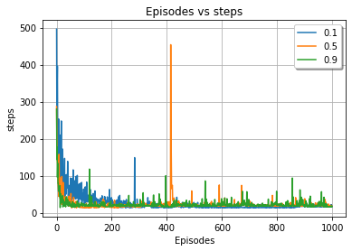

```python
_, ax = plt.subplots()
ax.plot(x, y, label="0.1")
ax.plot(a, b, label="0.5")
ax.plot(c, d, label="0.9")

ax.set(xlabel='Episodes', ylabel='steps',
       title='Episodes vs steps')
ax.grid()
ax.legend(shadow=True, fancybox=True)

plt.show()
```

**CONCLUSIONES:**  
Al realizar diversas simulaciones para diversos valores de learning rate podemos observar: - Al aumentar el learning rate la convergencia se acelera, pero llega un punto en que se vuelve inestable y con un learning rate de 0.9 el algoritmo no converge. - Con un learning rate bajo, de 0.1, la política del algoritmo es menos conservadora y encuentra la casilla de salida en 14 y 16 pasos, mientras que con un learning rate de 0.5 lo hace en 18 pasos. Aún así, no se consigue llegar a la política óptima de 12 pasos.